# corr_matrix

Jordan Lee

12/1/2020

# run step1_clean.ipynb first

# Base Section

https://uc-r.github.io/hc_clustering

https://stats.stackexchange.com/questions/2976/clustering-variables-based-on-correlations-between-them

```r
########## hardcoded
ftsets <- '../data/exact_match/best_models_BRCA.tsv'
upsetmode <- 'distinct'
init_vector <- c(clust1 = 0, clust2 = 0, clust3 = 0)#, clust4 = 0, clust5 = 0, clust6 = 0, clust7 = 0, clust8=0, clust9=0) # where len == n_clusters
team_order_upset <- c('JADBIO', 'CloudForest', 'AKLIMATE', 'SUBSCOPE', 'SciKitGrid')

file = '../data/heatmap/BRCA_vals_gexp.tsv'
cancer = 'BRCA'
datatype <- 'N:GEXP'

# n_clusters <- 4
##########
```

### Data Prep

Read in file containing Theo’s raw tarball values for features selected by teams (one best model per team). Reformat. Data format row:col:val is sample:feature:tarball_value

**TODO**

- rownames(df) line assumes the first col is the sample col

### Clustering features based on signal

Cluster features based on signal (from raw tarball).

1. Identify the strongest clustering structure of several methods `"average", "single", "complete", "ward"` for our data
2. Apply best clustering method in agglomerative clustering (AGNES) `agnes()`

Why AGNES instead of DIANA?

- Agglomerative clustering (AGNES). Won’t be using divisice hierarchial clustering (DIANA)
- Use `agnes()` instead of `hclust`

Agglomerative coefficient

- Measure of the clustering structure. “measure dissimilarity of object to the first cluster it joins, divided by the dissimilarity of the final merger in the cluster analysis, averaged across samples”. larger == larger strength of clustering
- AC tends to increase with sample size
- Can be compared to the silhouette coefficient

```
##      ward    single  complete   average
## 0.9893030 0.9860369 0.9852940 0.9845092
```

```
## [1] "method with largest agglomerative coefficient:"
```

```
## [1] "ward"
```

**A. hcut**

```r
library(factoextra)
```

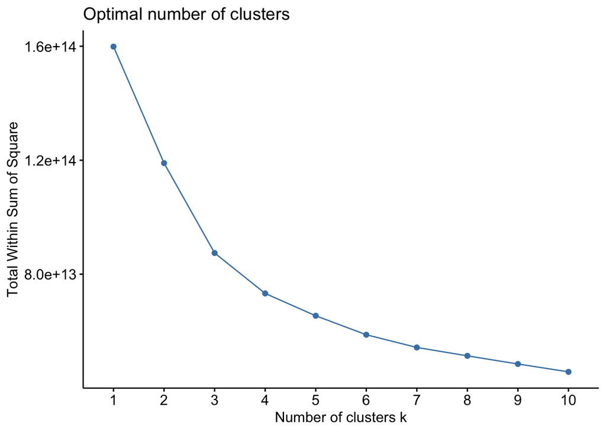

```r
library(NbClust)
# Find optimal n clusters
# 1. WSS
res_wss <-fviz_nbclust(df, FUNcluster = hcut, method = "wss", k.max = 10, print.summary = TRUE)
# print(res_wss$labels)
res_wss
```

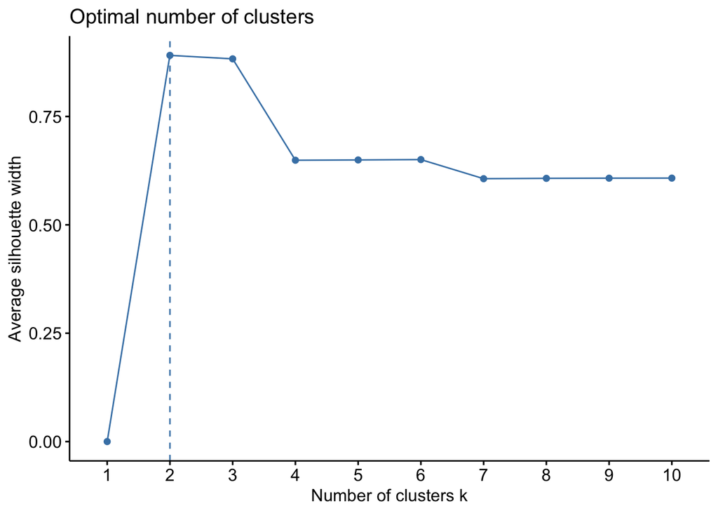

```r
# 2. Silhouette
res_sill <-fviz_nbclust(df, FUNcluster = hcut, method = "silhouette", k.max = 10, print.summary = TRUE)
res_sill
```

```r
# expand to print the opti number
data <- res_sill$data[order(res_sill$data$y, decreasing = TRUE),]
n_clusters <- data[1,1]
print('optimal number of clusters')
```

```
## [1] "optimal number of clusters"
```

```r
print(n_clusters)
```

```
## [1] 2
## Levels: 1 2 3 4 5 6 7 8 9 10
```

```r
# add one
n_clusters <- n_clusters %>% as.integer()+1
```

**B. Kmeans**

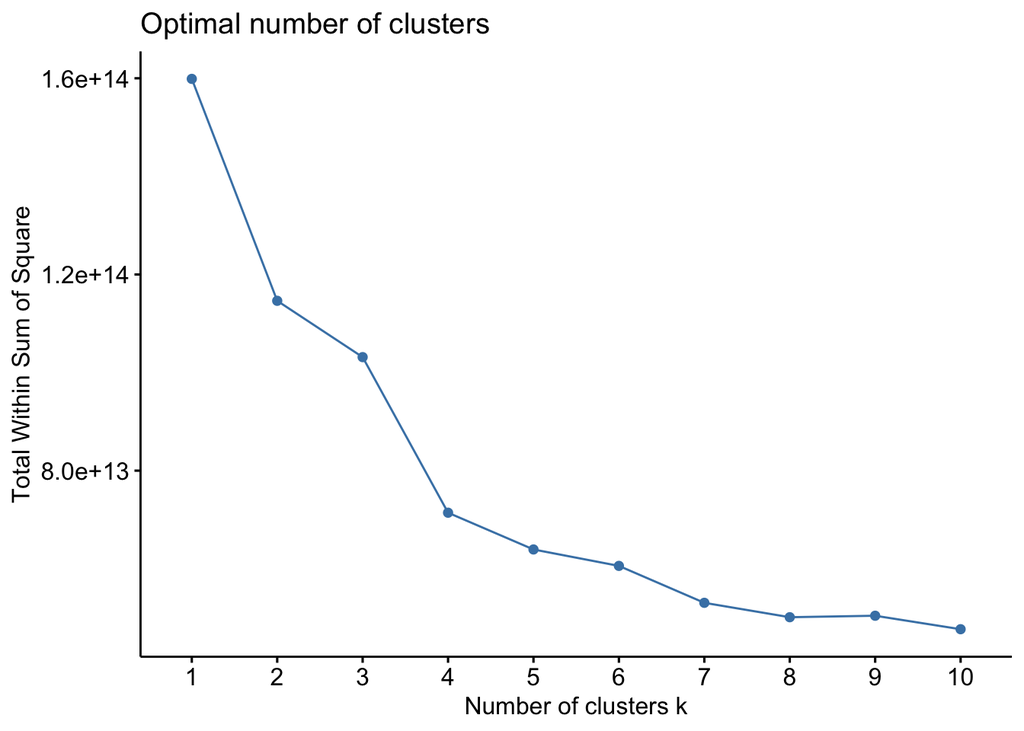

```r
# 1. kmeans clustering
fviz_nbclust(df, kmeans, method = "wss", print.summary = TRUE)
```

# 1. Using optimal number of clusters

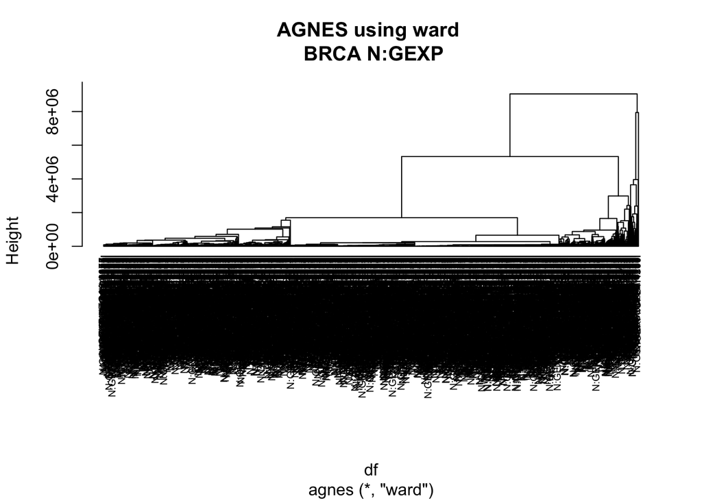

```r
# Plot
hc <- agnes(df, method = best_method)
pltree(hc, cex = 0.6, hang = -50, main = paste("AGNES using",best_method,'\n', cancer, datatype))
```

Visualize cluster members

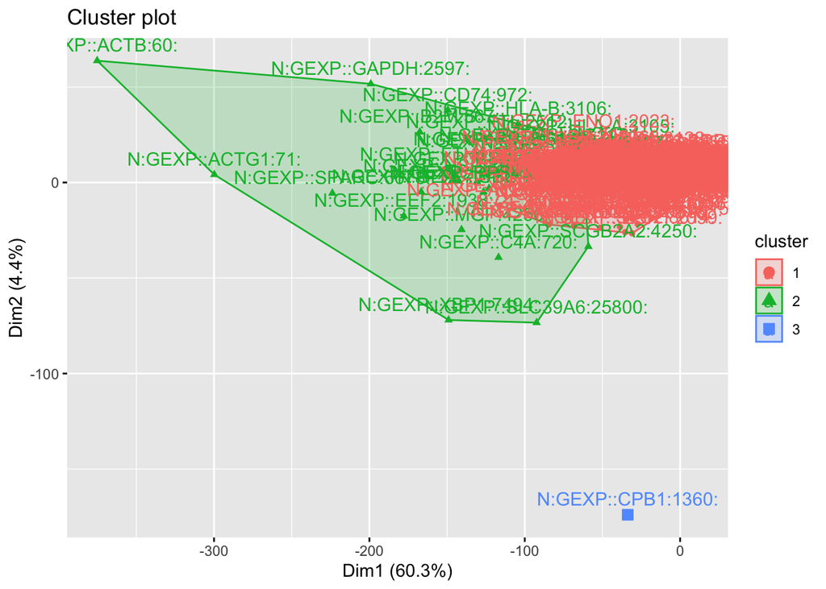

```r
fviz_cluster(list(data = df, cluster = clusterID))
```

How many features in each cluster?

| clusterID | n_members |
| --- | --- |
| 1 | 1655 |
| 2 | 26 |
| 3 | 1 |

Specifically which features? (head of data)

```
##      clusterID                    fts
## 302          2      N:GEXP::FTL:2512:
## 366          2     N:GEXP::RPL8:6132:
## 414          2     N:GEXP::XBP1:7494:
## 922          2 N:GEXP::SLC39A6:25800:
## 1570         2  N:GEXP::SCGB2A2:4250:
## 290          3     N:GEXP::CPB1:1360:
```

### Now examine in context of teams

Read in best model from each team. Which teams?

```
## [1] "gnosis_1_BRCA"
## [1] "found >= 1 ft"
## [1] "CF|All_Top 100_BRCA"
## [1] "found >= 1 ft"
## [1] "AKLIMATE_BRCA_reduced_model_1000_feature_set_BRCA"
## [1] "found >= 1 ft"
## [1] "nn_jg_2020-03-20_top1kfreq:BRCA_BRCA"
## [1] "found >= 1 ft"
## [1] "fbedeBIC_BRCA"
## [1] "found >= 1 ft"
```

Binary membership table

|  | gnosis_1_BRCA | CF\|All_Top 100_BRCA | AKLIMATE_BRCA_reduced_model_1000_feature_set_BRCA | nn_jg_2020-03-20_top1kfreq:BRCA_BRCA | fbedeBIC_BRCA |
| --- | --- | --- | --- | --- | --- |
| clust1 | 1 | 1 | 1 | 1 | 1 |
| clust2 | 0 | 1 | 1 | 1 | 0 |
| clust3 | 0 | 0 | 0 | 1 | 0 |

### Upset plot

Overlap of clusters

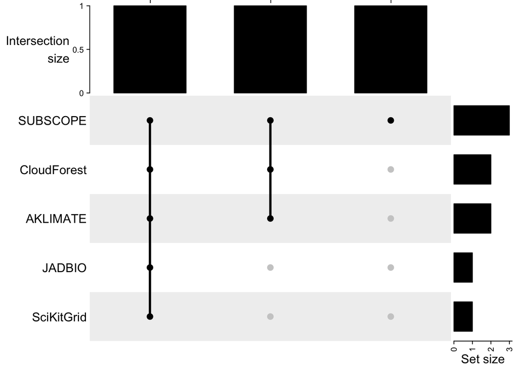

# 2. Now picking different values

```r
# iterate through these n_clusters
selected_clust <- c(3,4,5,6,7,8,9)
```

```
## [1] "n clusters:"
## [1] 3
## clust1 clust2 clust3
##      0      0      0
##
##
## |clusterID | n_members|
## |:---------|---------:|
## |1         |      1655|
## |2         |        26|
## |3         |         1|
##
##
## |     |clusterID |fts                    |
## |:----|:---------|:----------------------|
## |302  |2         |N:GEXP::FTL:2512:      |
## |366  |2         |N:GEXP::RPL8:6132:     |
## |414  |2         |N:GEXP::XBP1:7494:     |
## |922  |2         |N:GEXP::SLC39A6:25800: |
## |1570 |2         |N:GEXP::SCGB2A2:4250:  |
## |290  |3         |N:GEXP::CPB1:1360:     |
##
##
## |       | gnosis_1_BRCA| CF&#124;All_Top 100_BRCA| AKLIMATE_BRCA_reduced_model_1000_feature_set_BRCA| nn_jg_2020-03-20_top1kfreq:BRCA_BRCA| fbedeBIC_BRCA|
## |:------|-------------:|------------------------:|-------------------------------------------------:|------------------------------------:|-------------:|
## |clust1 |             1|                        1|                                                 1|                                    1|             1|
## |clust2 |             0|                        1|                                                 1|                                    1|             0|
## |clust3 |             0|                        0|                                                 0|                                    1|             0|
```

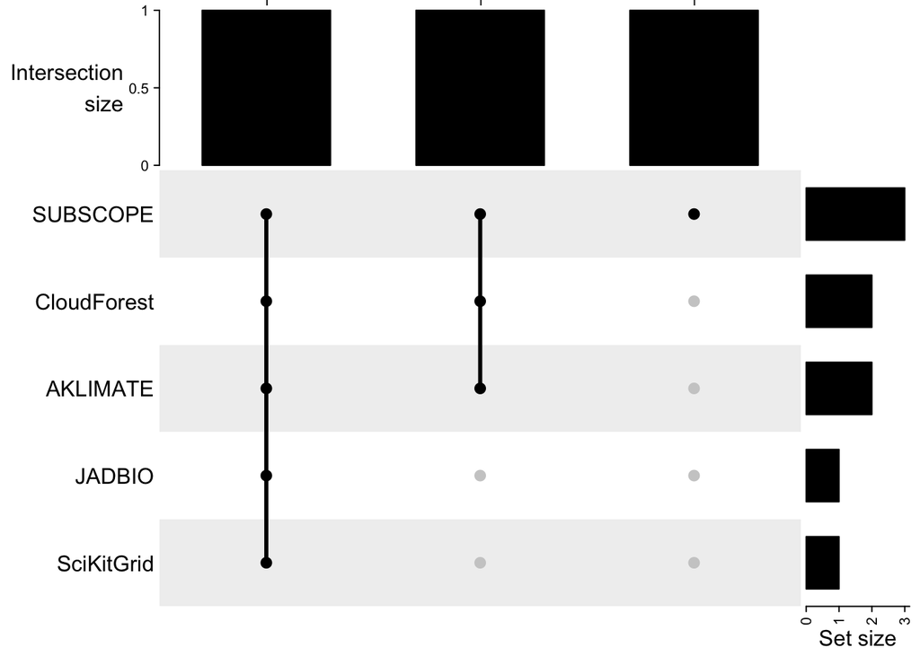

```
## [1] "n clusters:"
## [1] 4
## clust1 clust2 clust3 clust4
##      0      0      0      0
##
##
## |clusterID | n_members|
## |:---------|---------:|
## |1         |      1432|
## |2         |       223|
## |3         |        26|
## |4         |         1|
##
##
## |     |clusterID |fts                    |
## |:----|:---------|:----------------------|
## |302  |3         |N:GEXP::FTL:2512:      |
## |366  |3         |N:GEXP::RPL8:6132:     |
## |414  |3         |N:GEXP::XBP1:7494:     |
## |922  |3         |N:GEXP::SLC39A6:25800: |
## |1570 |3         |N:GEXP::SCGB2A2:4250:  |
## |290  |4         |N:GEXP::CPB1:1360:     |
##
##
## |       | gnosis_1_BRCA| CF&#124;All_Top 100_BRCA| AKLIMATE_BRCA_reduced_model_1000_feature_set_BRCA| nn_jg_2020-03-20_top1kfreq:BRCA_BRCA| fbedeBIC_BRCA|
## |:------|-------------:|------------------------:|-------------------------------------------------:|------------------------------------:|-------------:|
## |clust1 |             1|                        1|                                                 1|                                    1|             1|
## |clust2 |             1|                        1|                                                 1|                                    1|             1|
## |clust3 |             0|                        1|                                                 1|                                    1|             0|
## |clust4 |             0|                        0|                                                 0|                                    1|             0|
```

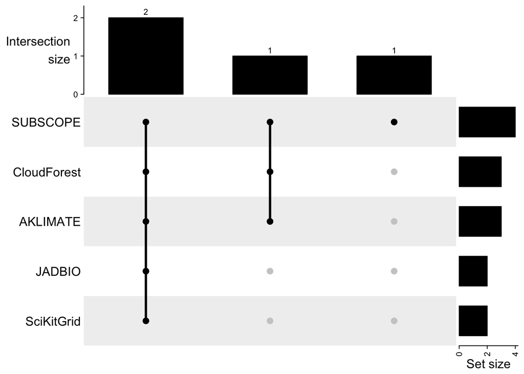

```
## [1] "n clusters:"
## [1] 5
## clust1 clust2 clust3 clust4 clust5
##      0      0      0      0      0
##
##
## |clusterID | n_members|
## |:---------|---------:|
## |1         |      1432|
## |2         |       223|
## |3         |        25|
## |4         |         1|
## |5         |         1|
##
##
## |     |clusterID |fts                    |
## |:----|:---------|:----------------------|
## |302  |3         |N:GEXP::FTL:2512:      |
## |366  |3         |N:GEXP::RPL8:6132:     |
## |414  |3         |N:GEXP::XBP1:7494:     |
## |922  |3         |N:GEXP::SLC39A6:25800: |
## |290  |4         |N:GEXP::CPB1:1360:     |
## |1570 |5         |N:GEXP::SCGB2A2:4250:  |
##
##
## |       | gnosis_1_BRCA| CF&#124;All_Top 100_BRCA| AKLIMATE_BRCA_reduced_model_1000_feature_set_BRCA| nn_jg_2020-03-20_top1kfreq:BRCA_BRCA| fbedeBIC_BRCA|
## |:------|-------------:|------------------------:|-------------------------------------------------:|------------------------------------:|-------------:|
## |clust1 |             1|                        1|                                                 1|                                    1|             1|
## |clust2 |             1|                        1|                                                 1|                                    1|             1|
## |clust3 |             0|                        1|                                                 1|                                    1|             0|
## |clust4 |             0|                        0|                                                 0|                                    1|             0|
## |clust5 |             0|                        0|                                                 1|                                    1|             0|
```

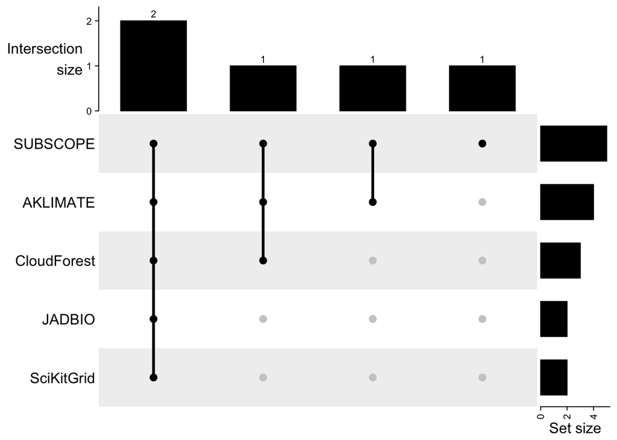

```
## [1] "n clusters:"
## [1] 6
## clust1 clust2 clust3 clust4 clust5 clust6
##      0      0      0      0      0      0
##
##
## |clusterID | n_members|
## |:---------|---------:|
## |1         |      1432|
## |2         |       223|
## |3         |         4|
## |4         |        21|
## |5         |         1|
## |6         |         1|
##
##
## |     |clusterID |fts                    |
## |:----|:---------|:----------------------|
## |302  |4         |N:GEXP::FTL:2512:      |
## |366  |4         |N:GEXP::RPL8:6132:     |
## |414  |4         |N:GEXP::XBP1:7494:     |
## |922  |4         |N:GEXP::SLC39A6:25800: |
## |290  |5         |N:GEXP::CPB1:1360:     |
## |1570 |6         |N:GEXP::SCGB2A2:4250:  |
##
##
## |       | gnosis_1_BRCA| CF&#124;All_Top 100_BRCA| AKLIMATE_BRCA_reduced_model_1000_feature_set_BRCA| nn_jg_2020-03-20_top1kfreq:BRCA_BRCA| fbedeBIC_BRCA|
## |:------|-------------:|------------------------:|-------------------------------------------------:|------------------------------------:|-------------:|
## |clust1 |             1|                        1|                                                 1|                                    1|             1|
## |clust2 |             1|                        1|                                                 1|                                    1|             1|
## |clust3 |             0|                        0|                                                 0|                                    1|             0|
## |clust4 |             0|                        1|                                                 1|                                    1|             0|
## |clust5 |             0|                        0|                                                 0|                                    1|             0|
## |clust6 |             0|                        0|                                                 1|                                    1|             0|
```

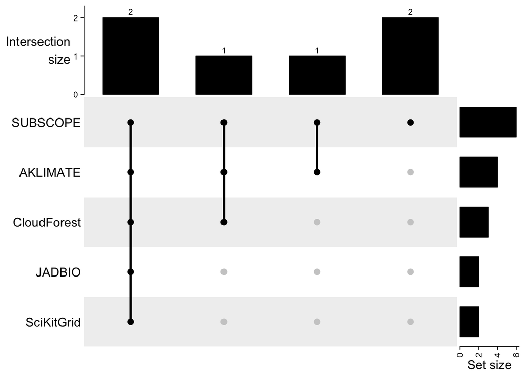

```
## [1] "n clusters:"
## [1] 7
## clust1 clust2 clust3 clust4 clust5 clust6 clust7
##      0      0      0      0      0      0      0
##
##
## |clusterID | n_members|
## |:---------|---------:|
## |1         |      1432|
## |2         |       182|
## |3         |         4|
## |4         |        41|
## |5         |        21|
## |6         |         1|
## |7         |         1|
##
##
## |     |clusterID |fts                    |
## |:----|:---------|:----------------------|
## |302  |5         |N:GEXP::FTL:2512:      |
## |366  |5         |N:GEXP::RPL8:6132:     |
## |414  |5         |N:GEXP::XBP1:7494:     |
## |922  |5         |N:GEXP::SLC39A6:25800: |
## |290  |6         |N:GEXP::CPB1:1360:     |
## |1570 |7         |N:GEXP::SCGB2A2:4250:  |
##
##
## |       | gnosis_1_BRCA| CF&#124;All_Top 100_BRCA| AKLIMATE_BRCA_reduced_model_1000_feature_set_BRCA| nn_jg_2020-03-20_top1kfreq:BRCA_BRCA| fbedeBIC_BRCA|
## |:------|-------------:|------------------------:|-------------------------------------------------:|------------------------------------:|-------------:|
## |clust1 |             1|                        1|                                                 1|                                    1|             1|
## |clust2 |             1|                        1|                                                 1|                                    1|             1|
## |clust3 |             0|                        0|                                                 0|                                    1|             0|
## |clust4 |             0|                        1|                                                 1|                                    1|             0|
## |clust5 |             0|                        1|                                                 1|                                    1|             0|
## |clust6 |             0|                        0|                                                 0|                                    1|             0|
## |clust7 |             0|                        0|                                                 1|                                    1|             0|
```

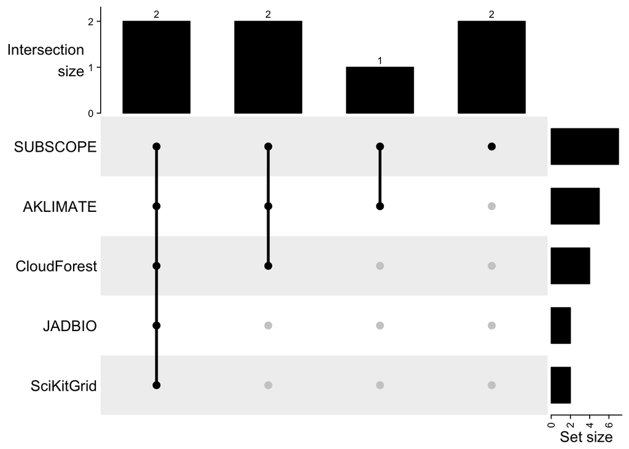

```
## [1] "n clusters:"
## [1] 8
## clust1 clust2 clust3 clust4 clust5 clust6 clust7 clust8
##      0      0      0      0      0      0      0      0
##
##
## |clusterID | n_members|
## |:---------|---------:|
## |1         |      1432|
## |2         |       182|
## |3         |         4|
## |4         |        39|
## |5         |        21|
## |6         |         2|
## |7         |         1|
## |8         |         1|
##
##
## |     |clusterID |fts                    |
## |:----|:---------|:----------------------|
## |414  |5         |N:GEXP::XBP1:7494:     |
## |922  |5         |N:GEXP::SLC39A6:25800: |
## |225  |6         |N:GEXP::ERBB2:2064:    |
## |545  |6         |N:GEXP::RPL19:6143:    |
## |290  |7         |N:GEXP::CPB1:1360:     |
## |1570 |8         |N:GEXP::SCGB2A2:4250:  |
##
##
## |       | gnosis_1_BRCA| CF&#124;All_Top 100_BRCA| AKLIMATE_BRCA_reduced_model_1000_feature_set_BRCA| nn_jg_2020-03-20_top1kfreq:BRCA_BRCA| fbedeBIC_BRCA|
## |:------|-------------:|------------------------:|-------------------------------------------------:|------------------------------------:|-------------:|
## |clust1 |             1|                        1|                                                 1|                                    1|             1|
## |clust2 |             1|                        1|                                                 1|                                    1|             1|
## |clust3 |             0|                        0|                                                 0|                                    1|             0|
## |clust4 |             0|                        0|                                                 1|                                    1|             0|
## |clust5 |             0|                        1|                                                 1|                                    1|             0|
## |clust6 |             0|                        1|                                                 1|                                    1|             0|
## |clust7 |             0|                        0|                                                 0|                                    1|             0|
## |clust8 |             0|                        0|                                                 1|                                    1|             0|
```

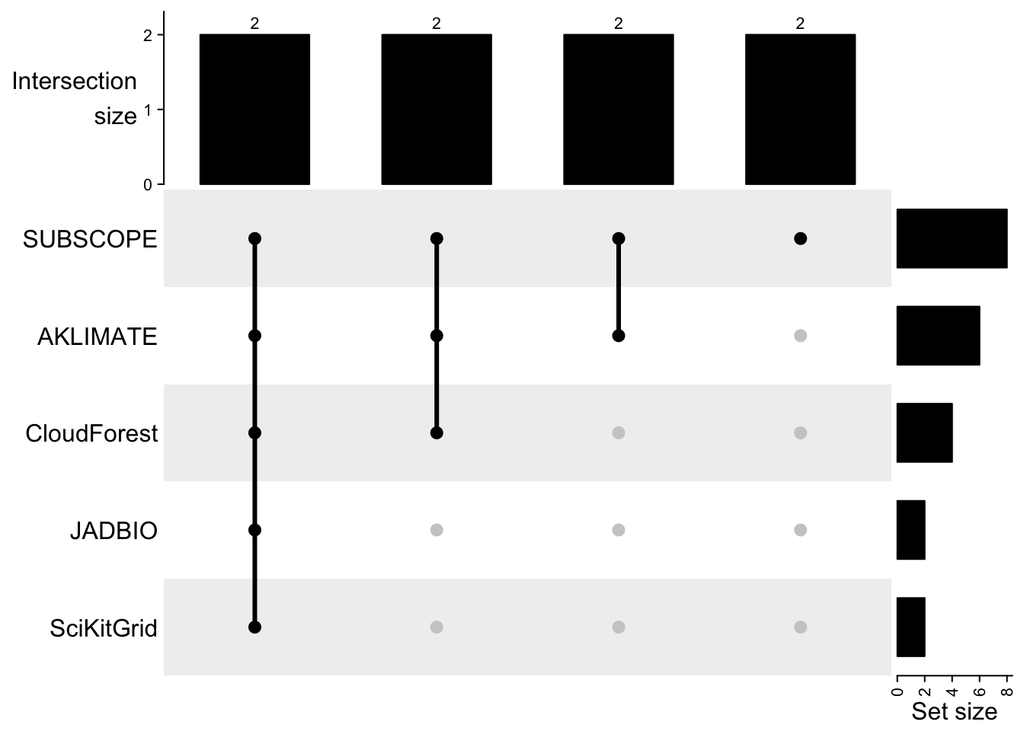

```
## [1] "n clusters:"
## [1] 9
## clust1 clust2 clust3 clust4 clust5 clust6 clust7 clust8 clust9
##      0      0      0      0      0      0      0      0      0
##
##
## |clusterID | n_members|
## |:---------|---------:|
## |1         |      1432|
## |2         |       182|
## |3         |         4|
## |4         |        39|
## |5         |        20|
## |6         |         1|
## |7         |         2|
## |8         |         1|
## |9         |         1|
##
##
## |     |clusterID |fts                    |
## |:----|:---------|:----------------------|
## |922  |5         |N:GEXP::SLC39A6:25800: |
## |41   |6         |N:GEXP::MGP:4256:      |
## |225  |7         |N:GEXP::ERBB2:2064:    |
## |545  |7         |N:GEXP::RPL19:6143:    |
## |290  |8         |N:GEXP::CPB1:1360:     |
## |1570 |9         |N:GEXP::SCGB2A2:4250:  |
##
##
## |       | gnosis_1_BRCA| CF&#124;All_Top 100_BRCA| AKLIMATE_BRCA_reduced_model_1000_feature_set_BRCA| nn_jg_2020-03-20_top1kfreq:BRCA_BRCA| fbedeBIC_BRCA|
## |:------|-------------:|------------------------:|-------------------------------------------------:|------------------------------------:|-------------:|
## |clust1 |             1|                        1|                                                 1|                                    1|             1|
## |clust2 |             1|                        1|                                                 1|                                    1|             1|
## |clust3 |             0|                        0|                                                 0|                                    1|             0|
## |clust4 |             0|                        0|                                                 1|                                    1|             0|
## |clust5 |             0|                        1|                                                 1|                                    1|             0|
## |clust6 |             0|                        0|                                                 0|                                    1|             0|
## |clust7 |             0|                        1|                                                 1|                                    1|             0|
## |clust8 |             0|                        0|                                                 0|                                    1|             0|
## |clust9 |             0|                        0|                                                 1|                                    1|             0|
```

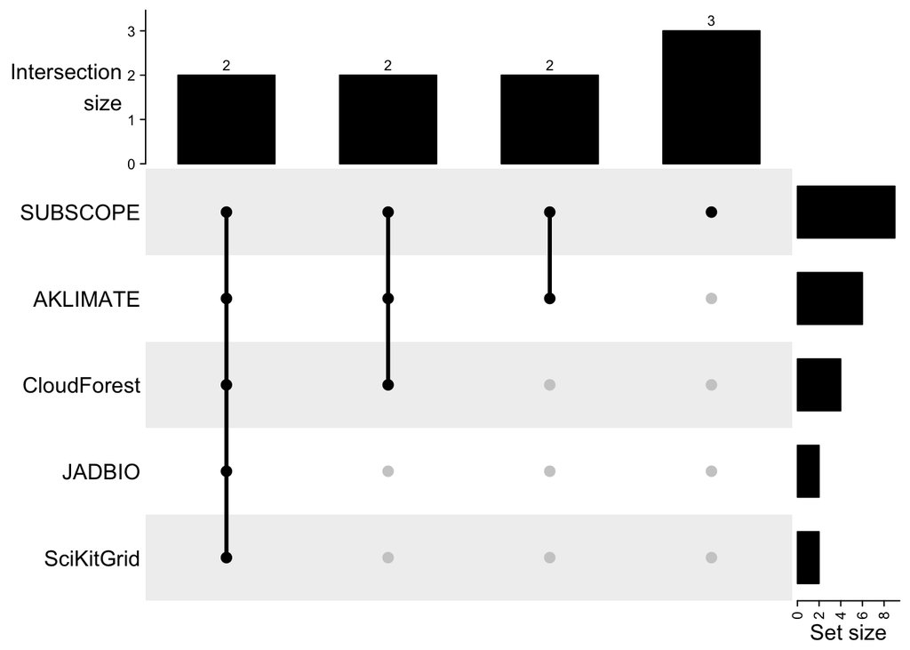